# Cryptocurrency Digest

Draft

Altfund Capital

12 June 2017

The digital currency Bitcoin has become immensely popular over the past few years. Wild price swings, massive heists from online marketplaces, and the general concept of a nationless, cryptography-based currency have captured the minds of many.

But what do the numbers actually say? And what about more recently introduced digital currencies such as Etherium and Ripple?

## Cryptos in Context

Let’s start by putting digital currencies in context with the global economy and parts of the financial system.

First, we can look at the market capitalization of cryptocurrencies compared to the Gross Domestic Products (GDPs) of some major countries:

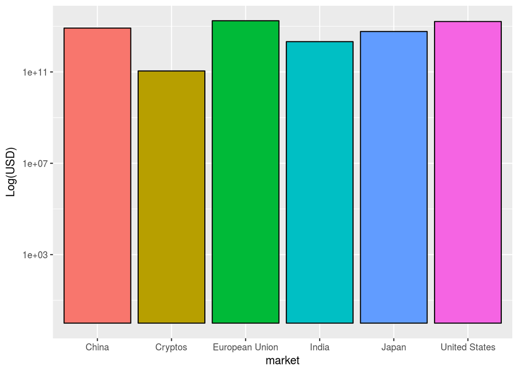

```r
crypto.market.cap <- global.crypto$total_market_cap_usd
crypto.trading.vol <- global.crypto$total_24h_volume_usd

market.stats <- data.frame(market=c("Cryptos", countries.long),
                           gdp=c(crypto.market.cap, mc$NY.GDP.MKTP.KD))

ggplot(data=market.stats, aes(x=market, y=gdp, fill=market)) +
  geom_bar(colour="black", stat="identity") +
  guides(fill=FALSE) + scale_y_log10(name="Log(USD)")
```

So, cryptocurrencies are pretty large, but a few orders of magnitude away from being a global player.

Next, let’s get a sense of just how volatile Bitcoin (or BTC, for short) has been by comparing its daily changes in price over the year so far with some popularly traded assets. We’ll use the S&P500 and Russell2000 to represent stocks, and the USD/GBP, USD/EUR, and USD/JPY currency pairs as other currencies for our benchmarks.

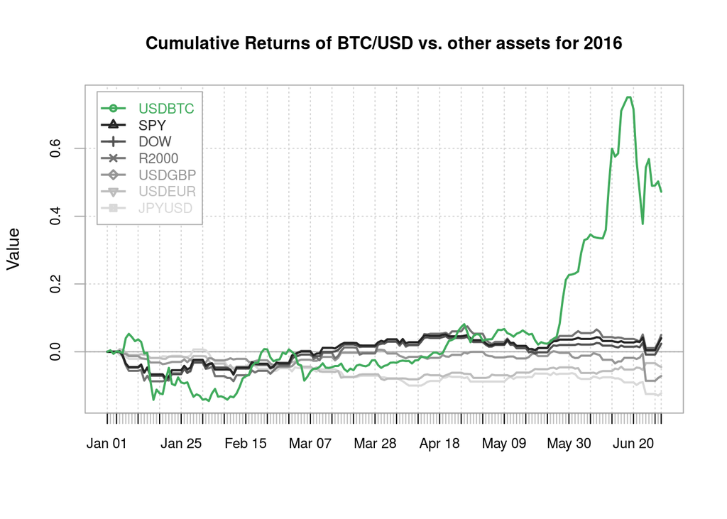

```r
# then return profiles
price.history <- list(
  USDBTC = getQuandlData("BCHARTS/COINBASEUSD")[,"Weighted Price"],
  SPY = getQuandlData("YAHOO/INDEX_SPY")[,"Adjusted Close"],
  DOW = getQuandlData("YAHOO/INDEX_DJI")[,"Adjusted Close"],
  R2000 = getQuandlData("YAHOO/INDEX_RUT")[,"Adjusted Close"],
  USDGBP = getQuandlData("BUNDESBANK/BBEX3_D_USD_GBP_CA_AC_000"), #USD/GBP
  USDEUR = getQuandlData("BOE/XUDLERD"), #USD/EUR
  JPYUSD = getQuandlData("BUNDESBANK/BBEX3_D_JPY_USD_CA_AC_000")
)
list.names <- names(price.history)
price.history <- do.call(merge, price.history)
names(price.history) <- list.names
# fix a known mistake point by removing it
price.history["2016-03-22","USDGBP"] <- NA

combined.price.history <- na.fill(CalculateReturns(price.history), fill=0)

# Green as highlight
greenfocus = c("#41AB5D", "#252525", "#525252", "#737373", "#969696", "#BDBDBD", "#D9D9D9", "#F0F0F0")
chart.CumReturns(combined.price.history, legend.loc = "topleft", colorset = greenfocus,
                 main="Cumulative Returns of BTC/USD vs. other assets for 2016")
```

Wow, pretty volatile huh? As we can see, even at their most stormy the major indeces of the US and UK were but calm ponds compared to the tsunami of BTC. Even Britain’s recent currency volatility surrounding Brexit looks rather tame by comparison. And how closely correlated are the movements in BTC to those of our basket? Not very:

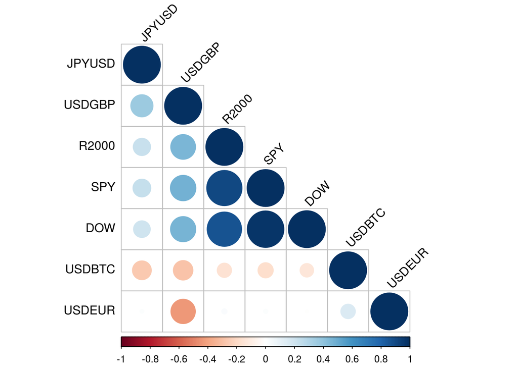

```r
corrplot(cor(combined.price.history), type="lower", order="hclust", tl.col="black", tl.srt=45)
```

## Comparing Apples to Apples

While digital currencies remain volatile, the market caps and trading volumes of these assets suggest that the asset class is maturing. It’s certainly too big to ignore. Let’s take a look at how the most widely traded cryptocurrencies have evolved over the past year.

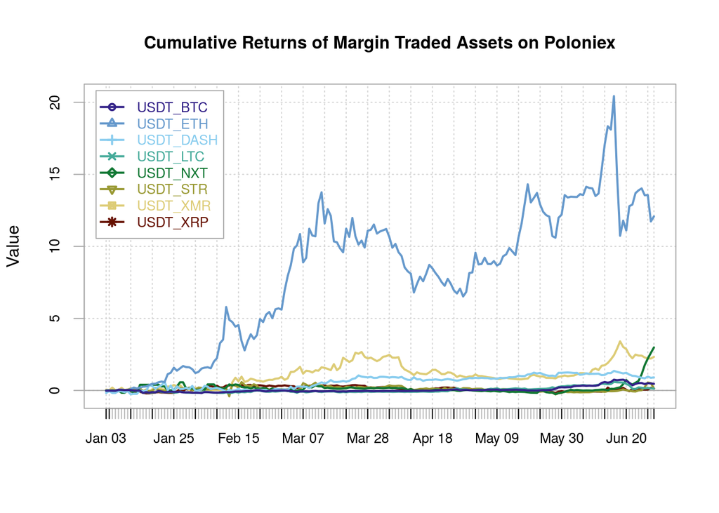

```r
# load and combine price data
margin.pairs <- c("BTC_BTS", "BTC_CLAM", "BTC_DASH", "BTC_DOGE", "BTC_ETH", "BTC_FCT"
                       , "BTC_LTC", "BTC_MAID", "BTC_STR", "BTC_XMR", "BTC_XRP")

pairs <- c("USDT_BTC","USDT_ETH", "USDT_DASH", "USDT_LTC", "USDT_NXT", "USDT_STR", "USDT_XMR", "USDT_XRP")
poloniex.data <- do.call(merge, lapply(pairs, getPoloniexData))

polo.returns <- na.omit(Return.calculate(poloniex.data))
tol11qualitative=c("#332288", "#6699CC", "#88CCEE", "#44AA99", "#117733", "#999933", "#DDCC77", "#661100", "#CC6677", "#882255", "#AA4499")

chart.CumReturns(polo.returns, legend.loc = "topleft", colorset = tol11qualitative,
                 main="Cumulative Returns of Margin Traded Assets on Poloniex")
```

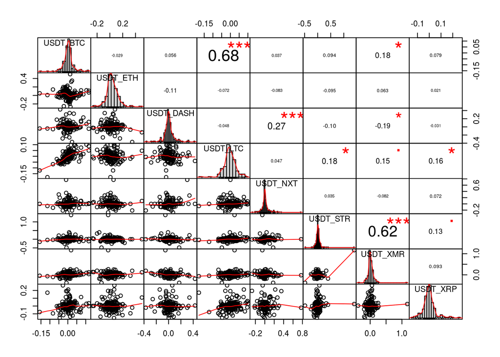

```r
chart.Correlation(polo.returns)
```

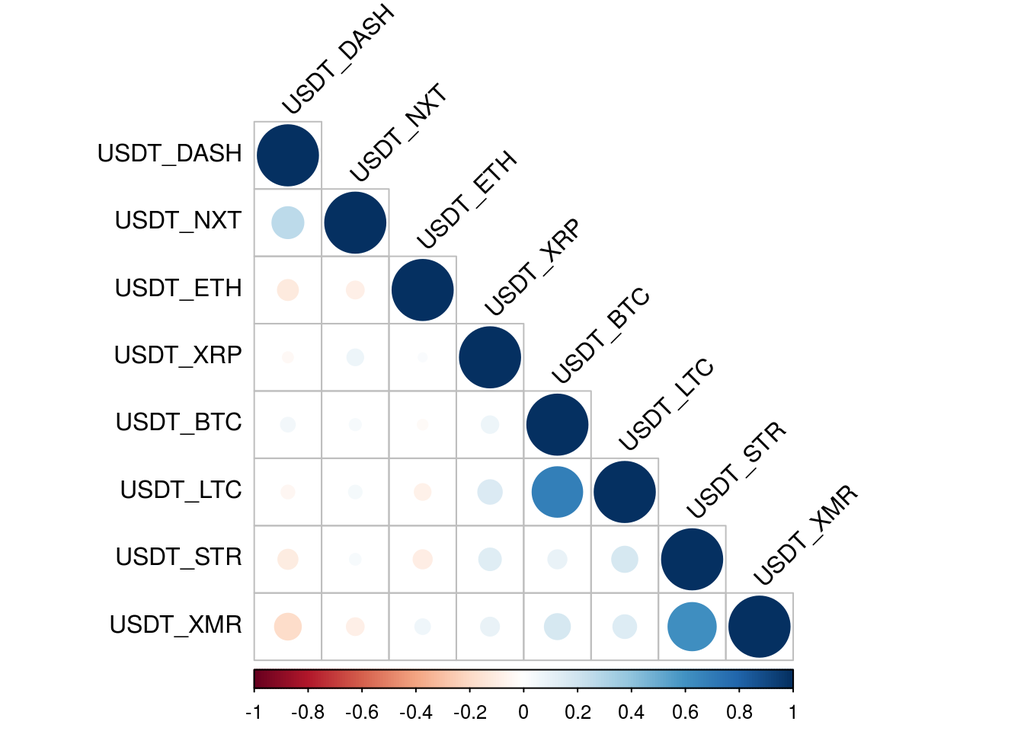

```r
corrplot(cor(polo.returns), type="lower", order="hclust", tl.col="black", tl.srt=45)
```

As we can see, these assets are slightly positively correlated with each other. However, let’s look at how they interact with the USDBTC pair. That is, when the amount of USD that can be purchased with one BTC rises, what happens to these currencies?

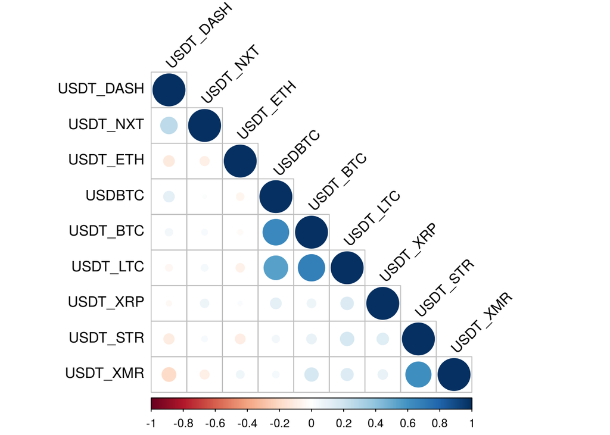

```r
corrplot(cor(na.omit(merge(polo.returns, combined.price.history$USDBTC))), type="lower", order="hclust", tl.col="black", tl.srt=45)
```

Hopefully this brief introduction to cryptocurrencies has given you some insights into the size of the market and how the assets have been acting this year.